# FM-1.8.0-alpha.1、FM-1.7.0与纯北单：三期固定规则比较

本报告比较用户批准的FM-1.8.0-alpha.1、正式FM-1.7.0与纯北单。另保留FM17-source-before-tail为组件对照：它取消尾部但不做让平重权，避免把两个改动混为同一收益。

**三期完整345场不支持升级alpha**：Top1为106/345、Top2为239/345，低于FM17的131/250和较晚北单130/244；Brier/log loss也略差。同截止214场中Top2和整体概率评分略有改善，但Top1明显下降。保留为已登记实验，不据结果修改参数或替换正式版本。

**原生λ取样／对手归一化实验没有整合进来**。alpha继承FM17的同一原生／联合市场来源裁决、λ和ρ，再按已登记规则校正；不重做定性审查、不新增阵容、伤停、战意或对手等级信息。已有完整流程版本不等于逐场这些维度都补齐。正式FM保持不变，不根据本次结果调整规则。

## 冻结、对照和合同

26098、26101、26102完整来源名单347场；无截止26098#135无预测，取消#102仍冻结预测但不评分；346场冻结、345场评分。alpha对全部346场执行，不只对54次已知让平漏保执行。源网格均为尾部前：触发时让平概率是它在净胜球前三档的占比，完整两侧分配剩余质量；不触发维持尾部前网格。边界并列整组纳入，定义保持alpha登记版本不变。

每场显式UTC截止绑定原source网格、fixture、整数北单让球、源证据和传递实现；共享temporal_learning负责证据准入和receipt核验。alpha_input与alpha_code绑定原始输入及导入校验器，cache_key区分cutoff/input/code。先完整冻结，再独立新进程重建346场并逐对象identical，之后评估脚本才读取标签／SP。此前赛果已知、规则由历史复盘启发，故这个程序边界不是独立盲测证据。源可用性仍为历史代理，不能自动取得前瞻准入。

冻结输出forecast artifact含完整比分、前后净胜球、三类概率和共享receipt；预测三行／fixture/model，比分一行／整数主客比分；所有概率为double 0—1且归一。审计一行／fixture，ID/期号字符、cutoff UTC POSIXct、trigger逻辑、让球整数。标签一行／fixture/score/actual_outcome，W/D/L按实际净胜球加有符号北单h映射，沿用原已核验标签，不重新改变比分口径。

纯北单为SP倒数归一化，未乘0.65。same_cutoff用严格早于T−24h的报价且selection_cutoff等于原fixture cutoff；near_sale为较晚赛前SP，不能冒充同截止。共同样本分别214、345，每个模型同一宇宙，另缺131场T−24h报价不补造。Top1/Top2沿用包W,D,L并列排序；Brier是三类平方误差和，log loss用自然对数，均越低越好。只比较预测，不计算票单收益或串关命中概率。

```r
suppressPackageStartupMessages(library(tidyverse))
root <- normalizePath(params$repository_root, mustWork = TRUE)
out <- file.path(root, params$output_directory)
manifest <- jsonlite::fromJSON(file.path(out, "manifest.json"))
replay <- jsonlite::fromJSON(file.path(out, "replay.json"))
stopifnot(replay$status == "FULL_IDENTICAL_REPLAY", replay$fixtures == 346L,
  digest::digest(file = file.path(out, "forecasts.rds"), algo = "sha256") == manifest$forecast_sha256)
log <- file.path(out, "qmd-evaluation.log")
status <- system2("/opt/R/4.6.1/bin/Rscript", shQuote(c(file.path(root, "r/fm18_three_issue_evaluate.R"), root, out)),
  env = paste0("R_LIBS=", shQuote(paste(.libPaths(), collapse = ":"))), stdout = log, stderr = log)
if (status != 0L) stop(paste(readLines(log), collapse = "\n"))
evaluation <- jsonlite::fromJSON(file.path(out, "evaluation.json"))
for (name in names(evaluation$output_hashes)) stopifnot(
  digest::digest(file = file.path(out, paste0(name, ".csv")), algo = "sha256") == evaluation$output_hashes[[name]])
metrics <- read_csv(file.path(out, "metrics.csv"), show_col_types = FALSE)
draw <- read_csv(file.path(out, "draw_calibration.csv"), show_col_types = FALSE)
changes <- read_csv(file.path(out, "changes.csv"), show_col_types = FALSE)
audit <- read_csv(file.path(out, "audit.csv"), col_types = cols(.default = col_guess(), issue_id = col_character()))
knitr::kable(audit |> count(issue_id, triggered), caption = "完整346场触发覆盖；含取消场，评分另行排除")
```

完整346场触发覆盖；含取消场，评分另行排除

| issue_id | triggered | n |
| --- | --- | --- |
| 26098 | FALSE | 4 |
| 26098 | TRUE | 141 |
| 26101 | FALSE | 8 |
| 26101 | TRUE | 107 |
| 26102 | FALSE | 3 |
| 26102 | TRUE | 83 |

## 同场总体及逐期表现

```r
knitr::kable(metrics |> filter(dimension == "all") |> select(comparison, model, n, hits1, hits2, top1, top2, brier, logloss),
  digits = 6, caption = "共同样本：三模型及不压尾组件对照；两时点分开")
```

共同样本：三模型及不压尾组件对照；两时点分开

| comparison | model | n | hits1 | hits2 | top1 | top2 | brier | logloss |
| --- | --- | --- | --- | --- | --- | --- | --- | --- |
| same_cutoff | BEIDAN_T24 | 214 | 71 | 149 | 0.331776 | 0.696262 | 0.780005 | 1.342765 |
| same_cutoff | FM-1.7.0 | 214 | 81 | 150 | 0.378505 | 0.700935 | 0.683462 | 1.121824 |
| same_cutoff | FM-1.8.0-alpha.1 | 214 | 64 | 153 | 0.299065 | 0.714953 | 0.680920 | 1.118920 |
| same_cutoff | FM17-source-before-tail | 214 | 80 | 143 | 0.373832 | 0.668224 | 0.684848 | 1.124691 |
| near_sale | BEIDAN_LATER | 345 | 130 | 244 | 0.376812 | 0.707246 | 0.670167 | 1.103727 |
| near_sale | FM-1.7.0 | 345 | 131 | 250 | 0.379710 | 0.724638 | 0.683364 | 1.120218 |
| near_sale | FM-1.8.0-alpha.1 | 345 | 106 | 239 | 0.307246 | 0.692754 | 0.686339 | 1.129082 |
| near_sale | FM17-source-before-tail | 345 | 129 | 244 | 0.373913 | 0.707246 | 0.683083 | 1.120975 |

```r
knitr::kable(metrics |> filter(dimension == "issue") |> select(comparison, stratum, model, n, hits1, hits2, brier, logloss),
  digits = 6, caption = "逐期全部结果，不只挑改善期")
```

逐期全部结果，不只挑改善期

| comparison | stratum | model | n | hits1 | hits2 | brier | logloss |
| --- | --- | --- | --- | --- | --- | --- | --- |
| same_cutoff | 26098 | BEIDAN_T24 | 105 | 35 | 76 | 0.856060 | 1.532699 |
| same_cutoff | 26098 | FM-1.7.0 | 105 | 42 | 75 | 0.660731 | 1.090628 |
| same_cutoff | 26098 | FM-1.8.0-alpha.1 | 105 | 35 | 75 | 0.665737 | 1.097973 |
| same_cutoff | 26098 | FM17-source-before-tail | 105 | 40 | 68 | 0.665193 | 1.098015 |
| same_cutoff | 26101 | BEIDAN_T24 | 89 | 31 | 59 | 0.689109 | 1.132464 |
| same_cutoff | 26101 | FM-1.7.0 | 89 | 32 | 62 | 0.707467 | 1.154544 |
| same_cutoff | 26101 | FM-1.8.0-alpha.1 | 89 | 23 | 65 | 0.696115 | 1.137225 |
| same_cutoff | 26101 | FM17-source-before-tail | 89 | 33 | 61 | 0.706876 | 1.154640 |
| same_cutoff | 26102 | BEIDAN_T24 | 20 | 5 | 14 | 0.785205 | 1.281444 |
| same_cutoff | 26102 | FM-1.7.0 | 20 | 7 | 13 | 0.695971 | 1.140005 |
| same_cutoff | 26102 | FM-1.8.0-alpha.1 | 20 | 6 | 13 | 0.693020 | 1.147439 |
| same_cutoff | 26102 | FM17-source-before-tail | 20 | 7 | 14 | 0.690013 | 1.131464 |
| near_sale | 26098 | BEIDAN_LATER | 144 | 57 | 105 | 0.663117 | 1.092623 |
| near_sale | 26098 | FM-1.7.0 | 144 | 56 | 102 | 0.661773 | 1.093062 |
| near_sale | 26098 | FM-1.8.0-alpha.1 | 144 | 45 | 98 | 0.673788 | 1.113645 |
| near_sale | 26098 | FM17-source-before-tail | 144 | 55 | 97 | 0.663862 | 1.096229 |
| near_sale | 26101 | BEIDAN_LATER | 115 | 37 | 71 | 0.701872 | 1.149811 |
| near_sale | 26101 | FM-1.7.0 | 115 | 42 | 83 | 0.727588 | 1.178635 |
| near_sale | 26101 | FM-1.8.0-alpha.1 | 115 | 29 | 86 | 0.716515 | 1.163903 |
| near_sale | 26101 | FM17-source-before-tail | 115 | 42 | 82 | 0.727394 | 1.182338 |
| near_sale | 26102 | BEIDAN_LATER | 86 | 36 | 68 | 0.639575 | 1.060697 |
| near_sale | 26102 | FM-1.7.0 | 86 | 33 | 65 | 0.660377 | 1.087573 |
| near_sale | 26102 | FM-1.8.0-alpha.1 | 86 | 32 | 55 | 0.667003 | 1.108366 |
| near_sale | 26102 | FM17-source-before-tail | 86 | 32 | 65 | 0.656014 | 1.080356 |

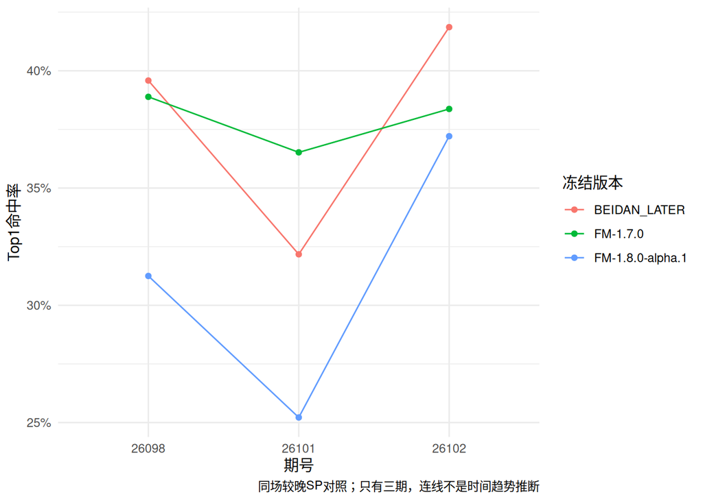

```r
metrics |> filter(dimension == "issue", comparison == "near_sale", model != "FM17-source-before-tail") |>
  ggplot(aes(stratum, top1, colour = model, group = model)) + geom_point() + geom_line() +
  scale_y_continuous(labels = scales::percent) + labs(x = "期号", y = "Top1命中率", colour = "冻结版本",
    caption = "同场较晚SP对照；只有三期，连线不是时间趋势推断") + theme_minimal()
```

## 赛事、来源及触发分层

```r
knitr::kable(metrics |> filter(dimension %in% c("event_type", "source", "trigger", "draw_type")), digits = 5,
  caption = "预设分层全部列出；来源是FM17路由，不表示北单也有相同路由")
```

预设分层全部列出；来源是FM17路由，不表示北单也有相同路由

| comparison | dimension | stratum | model | n | hits1 | hits2 | top1 | top2 | top3 | rank2 | rank3 | brier | logloss |
| --- | --- | --- | --- | --- | --- | --- | --- | --- | --- | --- | --- | --- | --- |
| same_cutoff | event_type | youth | BEIDAN_T24 | 7 | 3 | 5 | 0.42857 | 0.71429 | 1 | 0.28571 | 0.28571 | 1.07702 | 1.89487 |
| same_cutoff | event_type | youth | FM-1.7.0 | 7 | 2 | 6 | 0.28571 | 0.85714 | 1 | 0.57143 | 0.14286 | 0.70358 | 1.13433 |
| same_cutoff | event_type | youth | FM-1.8.0-alpha.1 | 7 | 2 | 4 | 0.28571 | 0.57143 | 1 | 0.28571 | 0.42857 | 0.68985 | 1.13630 |
| same_cutoff | event_type | youth | FM17-source-before-tail | 7 | 2 | 6 | 0.28571 | 0.85714 | 1 | 0.57143 | 0.14286 | 0.70250 | 1.13189 |
| same_cutoff | event_type | league | BEIDAN_T24 | 165 | 54 | 114 | 0.32727 | 0.69091 | 1 | 0.36364 | 0.30909 | 0.74861 | 1.29654 |
| same_cutoff | event_type | league | FM-1.7.0 | 165 | 61 | 115 | 0.36970 | 0.69697 | 1 | 0.32727 | 0.30303 | 0.68856 | 1.12906 |
| same_cutoff | event_type | league | FM-1.8.0-alpha.1 | 165 | 48 | 117 | 0.29091 | 0.70909 | 1 | 0.41818 | 0.29091 | 0.68759 | 1.12895 |
| same_cutoff | event_type | league | FM17-source-before-tail | 165 | 62 | 112 | 0.37576 | 0.67879 | 1 | 0.30303 | 0.32121 | 0.68768 | 1.12849 |
| same_cutoff | event_type | national | BEIDAN_T24 | 40 | 13 | 29 | 0.32500 | 0.72500 | 1 | 0.40000 | 0.27500 | 0.85809 | 1.43872 |
| same_cutoff | event_type | national | FM-1.7.0 | 40 | 17 | 28 | 0.42500 | 0.70000 | 1 | 0.27500 | 0.30000 | 0.66369 | 1.09644 |
| same_cutoff | event_type | national | FM-1.8.0-alpha.1 | 40 | 14 | 31 | 0.35000 | 0.77500 | 1 | 0.42500 | 0.22500 | 0.64903 | 1.07128 |
| same_cutoff | event_type | national | FM17-source-before-tail | 40 | 15 | 24 | 0.37500 | 0.60000 | 1 | 0.22500 | 0.40000 | 0.67541 | 1.11522 |
| same_cutoff | event_type | cup | BEIDAN_T24 | 2 | 1 | 1 | 0.50000 | 0.50000 | 1 | 0.00000 | 0.50000 | 0.76868 | 1.30502 |
| same_cutoff | event_type | cup | FM-1.7.0 | 2 | 1 | 1 | 0.50000 | 0.50000 | 1 | 0.00000 | 0.50000 | 0.58750 | 0.98905 |
| same_cutoff | event_type | cup | FM-1.8.0-alpha.1 | 2 | 0 | 1 | 0.00000 | 0.50000 | 1 | 0.50000 | 0.50000 | 0.73708 | 1.18325 |
| same_cutoff | event_type | cup | FM17-source-before-tail | 2 | 1 | 1 | 0.50000 | 0.50000 | 1 | 0.00000 | 0.50000 | 0.57821 | 0.97571 |
| same_cutoff | draw_type | nonzero_handicap | BEIDAN_T24 | 80 | 21 | 54 | 0.26250 | 0.67500 | 1 | 0.41250 | 0.32500 | 0.95647 | 1.73302 |
| same_cutoff | draw_type | nonzero_handicap | FM-1.7.0 | 80 | 27 | 52 | 0.33750 | 0.65000 | 1 | 0.31250 | 0.35000 | 0.73270 | 1.19111 |
| same_cutoff | draw_type | nonzero_handicap | FM-1.8.0-alpha.1 | 80 | 25 | 56 | 0.31250 | 0.70000 | 1 | 0.38750 | 0.30000 | 0.70029 | 1.14930 |
| same_cutoff | draw_type | nonzero_handicap | FM17-source-before-tail | 80 | 27 | 52 | 0.33750 | 0.65000 | 1 | 0.31250 | 0.35000 | 0.73081 | 1.19065 |
| same_cutoff | draw_type | zero_handicap | BEIDAN_T24 | 134 | 50 | 95 | 0.37313 | 0.70896 | 1 | 0.33582 | 0.29104 | 0.67465 | 1.10978 |
| same_cutoff | draw_type | zero_handicap | FM-1.7.0 | 134 | 54 | 98 | 0.40299 | 0.73134 | 1 | 0.32836 | 0.26866 | 0.65407 | 1.08046 |
| same_cutoff | draw_type | zero_handicap | FM-1.8.0-alpha.1 | 134 | 39 | 97 | 0.29104 | 0.72388 | 1 | 0.43284 | 0.27612 | 0.66936 | 1.10078 |
| same_cutoff | draw_type | zero_handicap | FM17-source-before-tail | 134 | 53 | 91 | 0.39552 | 0.67910 | 1 | 0.28358 | 0.32090 | 0.65741 | 1.08531 |
| same_cutoff | source | native | BEIDAN_T24 | 85 | 26 | 59 | 0.30588 | 0.69412 | 1 | 0.38824 | 0.30588 | 0.77267 | 1.30260 |
| same_cutoff | source | native | FM-1.7.0 | 85 | 23 | 56 | 0.27059 | 0.65882 | 1 | 0.38824 | 0.34118 | 0.74358 | 1.20469 |
| same_cutoff | source | native | FM-1.8.0-alpha.1 | 85 | 22 | 51 | 0.25882 | 0.60000 | 1 | 0.34118 | 0.40000 | 0.73575 | 1.20808 |
| same_cutoff | source | native | FM17-source-before-tail | 85 | 24 | 58 | 0.28235 | 0.68235 | 1 | 0.40000 | 0.31765 | 0.73841 | 1.19658 |
| same_cutoff | source | market | BEIDAN_T24 | 129 | 45 | 90 | 0.34884 | 0.69767 | 1 | 0.34884 | 0.30233 | 0.78484 | 1.36923 |
| same_cutoff | source | market | FM-1.7.0 | 129 | 58 | 94 | 0.44961 | 0.72868 | 1 | 0.27907 | 0.27132 | 0.64385 | 1.06722 |
| same_cutoff | source | market | FM-1.8.0-alpha.1 | 129 | 42 | 102 | 0.32558 | 0.79070 | 1 | 0.46512 | 0.20930 | 0.64479 | 1.06017 |
| same_cutoff | source | market | FM17-source-before-tail | 129 | 56 | 85 | 0.43411 | 0.65891 | 1 | 0.22481 | 0.34109 | 0.64955 | 1.07732 |
| same_cutoff | trigger | TRUE | BEIDAN_T24 | 211 | 71 | 148 | 0.33649 | 0.70142 | 1 | 0.36493 | 0.29858 | 0.77903 | 1.34235 |
| same_cutoff | trigger | TRUE | FM-1.7.0 | 211 | 80 | 147 | 0.37915 | 0.69668 | 1 | 0.31754 | 0.30332 | 0.68135 | 1.11987 |
| same_cutoff | trigger | TRUE | FM-1.8.0-alpha.1 | 211 | 63 | 150 | 0.29858 | 0.71090 | 1 | 0.41232 | 0.28910 | 0.67878 | 1.11637 |
| same_cutoff | trigger | TRUE | FM17-source-before-tail | 211 | 79 | 140 | 0.37441 | 0.66351 | 1 | 0.28910 | 0.33649 | 0.68276 | 1.12222 |
| same_cutoff | trigger | FALSE | BEIDAN_T24 | 3 | 0 | 1 | 0.00000 | 0.33333 | 1 | 0.33333 | 0.66667 | 0.84861 | 1.37175 |
| same_cutoff | trigger | FALSE | FM-1.7.0 | 3 | 1 | 3 | 0.33333 | 1.00000 | 1 | 0.66667 | 0.00000 | 0.83223 | 1.25959 |
| same_cutoff | trigger | FALSE | FM-1.8.0-alpha.1 | 3 | 1 | 3 | 0.33333 | 1.00000 | 1 | 0.66667 | 0.00000 | 0.83172 | 1.29853 |
| same_cutoff | trigger | FALSE | FM17-source-before-tail | 3 | 1 | 3 | 0.33333 | 1.00000 | 1 | 0.66667 | 0.00000 | 0.83172 | 1.29853 |
| near_sale | event_type | youth | BEIDAN_LATER | 43 | 19 | 36 | 0.44186 | 0.83721 | 1 | 0.39535 | 0.16279 | 0.62780 | 1.03452 |
| near_sale | event_type | youth | FM-1.7.0 | 43 | 21 | 38 | 0.48837 | 0.88372 | 1 | 0.39535 | 0.11628 | 0.59792 | 0.99151 |
| near_sale | event_type | youth | FM-1.8.0-alpha.1 | 43 | 14 | 25 | 0.32558 | 0.58140 | 1 | 0.25581 | 0.41860 | 0.65369 | 1.08446 |
| near_sale | event_type | youth | FM17-source-before-tail | 43 | 20 | 39 | 0.46512 | 0.90698 | 1 | 0.44186 | 0.09302 | 0.58820 | 0.97543 |
| near_sale | event_type | national | BEIDAN_LATER | 84 | 30 | 56 | 0.35714 | 0.66667 | 1 | 0.30952 | 0.33333 | 0.67577 | 1.11580 |
| near_sale | event_type | national | FM-1.7.0 | 84 | 34 | 57 | 0.40476 | 0.67857 | 1 | 0.27381 | 0.32143 | 0.68258 | 1.12853 |
| near_sale | event_type | national | FM-1.8.0-alpha.1 | 84 | 30 | 62 | 0.35714 | 0.73810 | 1 | 0.38095 | 0.26190 | 0.66563 | 1.10312 |
| near_sale | event_type | national | FM17-source-before-tail | 84 | 31 | 53 | 0.36905 | 0.63095 | 1 | 0.26190 | 0.36905 | 0.68865 | 1.13801 |
| near_sale | event_type | league | BEIDAN_LATER | 193 | 75 | 138 | 0.38860 | 0.71503 | 1 | 0.32642 | 0.28497 | 0.66819 | 1.10017 |
| near_sale | event_type | league | FM-1.7.0 | 193 | 70 | 134 | 0.36269 | 0.69430 | 1 | 0.33161 | 0.30570 | 0.68680 | 1.12614 |
| near_sale | event_type | league | FM-1.8.0-alpha.1 | 193 | 56 | 135 | 0.29016 | 0.69948 | 1 | 0.40933 | 0.30052 | 0.68876 | 1.13210 |
| near_sale | event_type | league | FM17-source-before-tail | 193 | 72 | 131 | 0.37306 | 0.67876 | 1 | 0.30570 | 0.32124 | 0.68629 | 1.12599 |
| near_sale | event_type | cup | BEIDAN_LATER | 25 | 6 | 14 | 0.24000 | 0.56000 | 1 | 0.32000 | 0.44000 | 0.73951 | 1.20968 |
| near_sale | event_type | cup | FM-1.7.0 | 25 | 6 | 21 | 0.24000 | 0.84000 | 1 | 0.60000 | 0.16000 | 0.80646 | 1.26794 |
| near_sale | event_type | cup | FM-1.8.0-alpha.1 | 25 | 6 | 17 | 0.24000 | 0.68000 | 1 | 0.44000 | 0.32000 | 0.79338 | 1.26978 |
| near_sale | event_type | cup | FM17-source-before-tail | 25 | 6 | 21 | 0.24000 | 0.84000 | 1 | 0.60000 | 0.16000 | 0.80279 | 1.27534 |
| near_sale | draw_type | nonzero_handicap | BEIDAN_LATER | 165 | 61 | 114 | 0.36970 | 0.69091 | 1 | 0.32121 | 0.30909 | 0.66130 | 1.09137 |
| near_sale | draw_type | nonzero_handicap | FM-1.7.0 | 165 | 65 | 122 | 0.39394 | 0.73939 | 1 | 0.34545 | 0.26061 | 0.69844 | 1.13812 |
| near_sale | draw_type | nonzero_handicap | FM-1.8.0-alpha.1 | 165 | 50 | 116 | 0.30303 | 0.70303 | 1 | 0.40000 | 0.29697 | 0.69175 | 1.13485 |
| near_sale | draw_type | nonzero_handicap | FM17-source-before-tail | 165 | 65 | 122 | 0.39394 | 0.73939 | 1 | 0.34545 | 0.26061 | 0.69462 | 1.13606 |
| near_sale | draw_type | zero_handicap | BEIDAN_LATER | 180 | 69 | 130 | 0.38333 | 0.72222 | 1 | 0.33889 | 0.27778 | 0.67830 | 1.11506 |
| near_sale | draw_type | zero_handicap | FM-1.7.0 | 180 | 66 | 128 | 0.36667 | 0.71111 | 1 | 0.34444 | 0.28889 | 0.66954 | 1.10381 |
| near_sale | draw_type | zero_handicap | FM-1.8.0-alpha.1 | 180 | 56 | 123 | 0.31111 | 0.68333 | 1 | 0.37222 | 0.31667 | 0.68138 | 1.12380 |
| near_sale | draw_type | zero_handicap | FM17-source-before-tail | 180 | 64 | 122 | 0.35556 | 0.67778 | 1 | 0.32222 | 0.32222 | 0.67250 | 1.10715 |
| near_sale | source | market | BEIDAN_LATER | 228 | 88 | 165 | 0.38596 | 0.72368 | 1 | 0.33772 | 0.27632 | 0.66138 | 1.09174 |
| near_sale | source | market | FM-1.7.0 | 228 | 98 | 165 | 0.42982 | 0.72368 | 1 | 0.29386 | 0.27632 | 0.65374 | 1.08120 |
| near_sale | source | market | FM-1.8.0-alpha.1 | 228 | 73 | 166 | 0.32018 | 0.72807 | 1 | 0.40789 | 0.27193 | 0.66084 | 1.08967 |
| near_sale | source | market | FM17-source-before-tail | 228 | 95 | 158 | 0.41667 | 0.69298 | 1 | 0.27632 | 0.30702 | 0.65545 | 1.08434 |
| near_sale | source | native | BEIDAN_LATER | 117 | 42 | 79 | 0.35897 | 0.67521 | 1 | 0.31624 | 0.32479 | 0.68729 | 1.12708 |
| near_sale | source | native | FM-1.7.0 | 117 | 33 | 85 | 0.28205 | 0.72650 | 1 | 0.44444 | 0.27350 | 0.74109 | 1.19624 |
| near_sale | source | native | FM-1.8.0-alpha.1 | 117 | 33 | 73 | 0.28205 | 0.62393 | 1 | 0.34188 | 0.37607 | 0.73604 | 1.20587 |
| near_sale | source | native | FM17-source-before-tail | 117 | 34 | 86 | 0.29060 | 0.73504 | 1 | 0.44444 | 0.26496 | 0.73694 | 1.19236 |
| near_sale | trigger | TRUE | BEIDAN_LATER | 330 | 125 | 236 | 0.37879 | 0.71515 | 1 | 0.33636 | 0.28485 | 0.66924 | 1.10183 |
| near_sale | trigger | TRUE | FM-1.7.0 | 330 | 124 | 235 | 0.37576 | 0.71212 | 1 | 0.33636 | 0.28788 | 0.68107 | 1.11904 |
| near_sale | trigger | TRUE | FM-1.8.0-alpha.1 | 330 | 99 | 224 | 0.30000 | 0.67879 | 1 | 0.37879 | 0.32121 | 0.68415 | 1.12681 |
| near_sale | trigger | TRUE | FM17-source-before-tail | 330 | 122 | 229 | 0.36970 | 0.69394 | 1 | 0.32424 | 0.30606 | 0.68075 | 1.11833 |
| near_sale | trigger | FALSE | BEIDAN_LATER | 15 | 5 | 8 | 0.33333 | 0.53333 | 1 | 0.20000 | 0.46667 | 0.69051 | 1.14551 |
| near_sale | trigger | FALSE | FM-1.7.0 | 15 | 7 | 15 | 0.46667 | 1.00000 | 1 | 0.53333 | 0.00000 | 0.73377 | 1.14621 |
| near_sale | trigger | FALSE | FM-1.8.0-alpha.1 | 15 | 7 | 15 | 0.46667 | 1.00000 | 1 | 0.53333 | 0.00000 | 0.73448 | 1.17915 |
| near_sale | trigger | FALSE | FM17-source-before-tail | 15 | 7 | 15 | 0.46667 | 1.00000 | 1 | 0.53333 | 0.00000 | 0.73448 | 1.17915 |

同赛事均值与对手归一化没有加入，因此不能把本表变化归因于它们。原生／市场组比赛不同，也不能仅凭两组命中差推导来源切换的因果效果。触发规则在大部分场次生效，不能把它解释成只对少量失误的补丁。

## 让平概率与选择代价

已评分345场中330场触发。让平被选为Top1的场次从FM17的5场升至alpha的211场，其中命中61场。实际让平110场（31.88%），alpha平均给38.03%，由FM17的低估转为高估。让平二元Brier从0.22201升至0.22819，不能因漏保归零就认为让平概率更准确。

Top2救回54场全部是让平；与此同时丢失让胜42场、让负23场，净少11场。Top1新增58场让平命中，丢失让胜57场、让负26场，净少25场。仅取消尾部的控制组129/244，alpha再变为106/239，说明退步不能全部归因于取消尾部；按前三档相对占比提高让平是另一个主要变化。

```r
knitr::kable(draw |> filter(dimension %in% c("all", "draw_type", "issue")), digits = 6,
  caption = "让平预测概率、实际发生率和二元Brier；零让球／非零让球分开")
```

让平预测概率、实际发生率和二元Brier；零让球／非零让球分开

| comparison | dimension | stratum | model | n | actual_draws | mean_draw_probability | actual_draw_rate | binary_draw_brier |
| --- | --- | --- | --- | --- | --- | --- | --- | --- |
| same_cutoff | all | ALL | BEIDAN_T24 | 214 | 73 | 0.233304 | 0.341121 | 0.245033 |
| same_cutoff | all | ALL | FM-1.7.0 | 214 | 73 | 0.272679 | 0.341121 | 0.231668 |
| same_cutoff | all | ALL | FM-1.8.0-alpha.1 | 214 | 73 | 0.393167 | 0.341121 | 0.232558 |
| same_cutoff | all | ALL | FM17-source-before-tail | 214 | 73 | 0.258735 | 0.341121 | 0.233621 |
| same_cutoff | issue | 26098 | BEIDAN_T24 | 105 | 35 | 0.199926 | 0.333333 | 0.250288 |
| same_cutoff | issue | 26098 | FM-1.7.0 | 105 | 35 | 0.273265 | 0.333333 | 0.221873 |
| same_cutoff | issue | 26098 | FM-1.8.0-alpha.1 | 105 | 35 | 0.397697 | 0.333333 | 0.225234 |
| same_cutoff | issue | 26098 | FM17-source-before-tail | 105 | 35 | 0.258926 | 0.333333 | 0.224532 |
| same_cutoff | issue | 26101 | BEIDAN_T24 | 89 | 32 | 0.279053 | 0.359551 | 0.243959 |
| same_cutoff | issue | 26101 | FM-1.7.0 | 89 | 32 | 0.271045 | 0.359551 | 0.248264 |
| same_cutoff | issue | 26101 | FM-1.8.0-alpha.1 | 89 | 32 | 0.387325 | 0.359551 | 0.244900 |
| same_cutoff | issue | 26101 | FM17-source-before-tail | 89 | 32 | 0.257054 | 0.359551 | 0.249877 |
| same_cutoff | issue | 26102 | BEIDAN_T24 | 20 | 6 | 0.204960 | 0.300000 | 0.222225 |
| same_cutoff | issue | 26102 | FM-1.7.0 | 20 | 6 | 0.276875 | 0.300000 | 0.209242 |
| same_cutoff | issue | 26102 | FM-1.8.0-alpha.1 | 20 | 6 | 0.395376 | 0.300000 | 0.216085 |
| same_cutoff | issue | 26102 | FM17-source-before-tail | 20 | 6 | 0.265209 | 0.300000 | 0.209005 |
| same_cutoff | draw_type | nonzero_handicap | BEIDAN_T24 | 80 | 29 | 0.156617 | 0.362500 | 0.282106 |
| same_cutoff | draw_type | nonzero_handicap | FM-1.7.0 | 80 | 29 | 0.232664 | 0.362500 | 0.249857 |
| same_cutoff | draw_type | nonzero_handicap | FM-1.8.0-alpha.1 | 80 | 29 | 0.340673 | 0.362500 | 0.237442 |
| same_cutoff | draw_type | nonzero_handicap | FM17-source-before-tail | 80 | 29 | 0.220865 | 0.362500 | 0.253039 |
| same_cutoff | draw_type | zero_handicap | BEIDAN_T24 | 134 | 44 | 0.279088 | 0.328358 | 0.222900 |
| same_cutoff | draw_type | zero_handicap | FM-1.7.0 | 134 | 44 | 0.296569 | 0.328358 | 0.220809 |
| same_cutoff | draw_type | zero_handicap | FM-1.8.0-alpha.1 | 134 | 44 | 0.424506 | 0.328358 | 0.229642 |
| same_cutoff | draw_type | zero_handicap | FM17-source-before-tail | 134 | 44 | 0.281344 | 0.328358 | 0.222029 |
| near_sale | all | ALL | BEIDAN_LATER | 345 | 110 | 0.273775 | 0.318841 | 0.220474 |
| near_sale | all | ALL | FM-1.7.0 | 345 | 110 | 0.264390 | 0.318841 | 0.222013 |
| near_sale | all | ALL | FM-1.8.0-alpha.1 | 345 | 110 | 0.380343 | 0.318841 | 0.228188 |
| near_sale | all | ALL | FM17-source-before-tail | 345 | 110 | 0.250660 | 0.318841 | 0.223619 |
| near_sale | issue | 26098 | BEIDAN_LATER | 144 | 43 | 0.267065 | 0.298611 | 0.207813 |
| near_sale | issue | 26098 | FM-1.7.0 | 144 | 43 | 0.266697 | 0.298611 | 0.208105 |
| near_sale | issue | 26098 | FM-1.8.0-alpha.1 | 144 | 43 | 0.387190 | 0.298611 | 0.217892 |
| near_sale | issue | 26098 | FM17-source-before-tail | 144 | 43 | 0.252719 | 0.298611 | 0.209650 |
| near_sale | issue | 26101 | BEIDAN_LATER | 115 | 44 | 0.280118 | 0.382609 | 0.255957 |
| near_sale | issue | 26101 | FM-1.7.0 | 115 | 44 | 0.263826 | 0.382609 | 0.265187 |
| near_sale | issue | 26101 | FM-1.8.0-alpha.1 | 115 | 44 | 0.374549 | 0.382609 | 0.262288 |
| near_sale | issue | 26101 | FM17-source-before-tail | 115 | 44 | 0.250038 | 0.382609 | 0.267532 |
| near_sale | issue | 26102 | BEIDAN_LATER | 86 | 23 | 0.276527 | 0.267442 | 0.194226 |
| near_sale | issue | 26102 | FM-1.7.0 | 86 | 23 | 0.261282 | 0.267442 | 0.187569 |
| near_sale | issue | 26102 | FM-1.8.0-alpha.1 | 86 | 23 | 0.376626 | 0.267442 | 0.199831 |
| near_sale | issue | 26102 | FM17-source-before-tail | 86 | 23 | 0.248044 | 0.267442 | 0.188290 |
| near_sale | draw_type | nonzero_handicap | BEIDAN_LATER | 165 | 51 | 0.274241 | 0.309091 | 0.216178 |
| near_sale | draw_type | nonzero_handicap | FM-1.7.0 | 165 | 51 | 0.229802 | 0.309091 | 0.225426 |
| near_sale | draw_type | nonzero_handicap | FM-1.8.0-alpha.1 | 165 | 51 | 0.332788 | 0.309091 | 0.227990 |
| near_sale | draw_type | nonzero_handicap | FM17-source-before-tail | 165 | 51 | 0.217780 | 0.309091 | 0.227108 |
| near_sale | draw_type | zero_handicap | BEIDAN_LATER | 180 | 59 | 0.273348 | 0.327778 | 0.224412 |
| near_sale | draw_type | zero_handicap | FM-1.7.0 | 180 | 59 | 0.296097 | 0.327778 | 0.218884 |
| near_sale | draw_type | zero_handicap | FM-1.8.0-alpha.1 | 180 | 59 | 0.423935 | 0.327778 | 0.228370 |
| near_sale | draw_type | zero_handicap | FM17-source-before-tail | 180 | 59 | 0.280799 | 0.327778 | 0.220422 |

```r
knitr::kable(read_csv(file.path(out, "draw_selection.csv"), show_col_types = FALSE),
  caption = "让平主选数量、实际主选命中及Top2漏掉让平数量；排名变化不等于概率校准")
```

让平主选数量、实际主选命中及Top2漏掉让平数量；排名变化不等于概率校准

| model | n | draw_top1_count | draw_top1_hits | missed_draws_top2 |
| --- | --- | --- | --- | --- |
| BEIDAN_LATER | 345 | 8 | 0 | 50 |
| FM-1.7.0 | 345 | 5 | 3 | 54 |
| FM-1.8.0-alpha.1 | 345 | 211 | 61 | 0 |
| FM17-source-before-tail | 345 | 0 | 0 | 73 |

```r
knitr::kable(changes |> group_by(actual_outcome) |> summarise(n = n(), saved_top1 = sum(saved_top1),
  lost_top1 = sum(lost_top1), saved_top2 = sum(saved_top2), lost_top2 = sum(lost_top2),
  mean_brier_delta = mean(brier_delta), .groups = "drop"), digits = 6,
  caption = "alpha相对FM17：按实际W/D/L列出救回与损失，正Brier差表示退步")
```

alpha相对FM17：按实际W/D/L列出救回与损失，正Brier差表示退步

| actual_outcome | n | saved_top1 | lost_top1 | saved_top2 | lost_top2 | mean_brier_delta |
| --- | --- | --- | --- | --- | --- | --- |
| D | 110 | 58 | 0 | 54 | 0 | -0.229927 |
| L | 103 | 0 | 26 | 0 | 23 | 0.107922 |
| W | 132 | 0 | 57 | 0 | 42 | 0.115171 |

```r
knitr::kable(changes |> group_by(issue_id) |> summarise(n = n(), saved_top1 = sum(saved_top1),
  lost_top1 = sum(lost_top1), saved_top2 = sum(saved_top2), lost_top2 = sum(lost_top2), .groups = "drop"),
  caption = "逐期救回／损失完整账本")
```

逐期救回／损失完整账本

| issue_id | n | saved_top1 | lost_top1 | saved_top2 | lost_top2 |
| --- | --- | --- | --- | --- | --- |
| 26098 | 144 | 26 | 37 | 25 | 29 |
| 26101 | 115 | 17 | 30 | 17 | 14 |
| 26102 | 86 | 15 | 16 | 12 | 22 |

```r
knitr::kable(changes |> filter(saved_top1 | lost_top1 | saved_top2 | lost_top2) |>
  select(fixture_id, home, away, league, handicap, actual_outcome, fm_rank, alpha_rank,
    triggered, saved_top1, lost_top1, saved_top2, lost_top2, brier_delta), digits = 5,
  caption = "所有排名救回或损失场次，非只展示典型成功")
```

所有排名救回或损失场次，非只展示典型成功

| fixture_id | home | away | league | handicap | actual_outcome | fm_rank | alpha_rank | triggered | saved_top1 | lost_top1 | saved_top2 | lost_top2 | brier_delta |
| --- | --- | --- | --- | --- | --- | --- | --- | --- | --- | --- | --- | --- | --- |
| 26098:1 | 乌兹别克斯坦亚运男足 | 沙特阿拉伯亚运男足 | 亚运男足 | -1 | W | 2 | 3 | TRUE | FALSE | FALSE | FALSE | TRUE | 0.05762 |
| 26098:100 | 夏洛特FC | 芝加哥火焰 | 美职业 | 0 | L | 2 | 3 | TRUE | FALSE | FALSE | FALSE | TRUE | 0.08586 |
| 26098:101 | CF蒙特利尔 | FC辛辛那提 | 美职业 | 0 | W | 1 | 2 | TRUE | FALSE | TRUE | FALSE | FALSE | 0.18556 |
| 26098:104 | 奥斯汀FC | 圣迭戈FC | 美职业 | 0 | D | 3 | 1 | TRUE | TRUE | FALSE | TRUE | FALSE | -0.26963 |
| 26098:105 | FC达拉斯 | 洛杉矶FC | 美职业 | 0 | W | 1 | 2 | TRUE | FALSE | TRUE | FALSE | FALSE | 0.18295 |
| 26098:106 | 休斯顿迪纳摩 | 堪萨斯城体育 | 美职业 | -1 | L | 2 | 3 | TRUE | FALSE | FALSE | FALSE | TRUE | 0.07829 |
| 26098:108 | 西雅图海湾人 | 明尼苏达联 | 美职业 | 0 | W | 1 | 2 | TRUE | FALSE | TRUE | FALSE | FALSE | 0.18433 |
| 26098:109 | 皇家盐湖城 | 新英格兰 | 美职业 | 0 | W | 2 | 3 | TRUE | FALSE | FALSE | FALSE | TRUE | 0.09977 |
| 26098:110 | 洛杉矶 | 科罗拉多急流 | 美职业 | 0 | W | 1 | 2 | TRUE | FALSE | TRUE | FALSE | FALSE | 0.18565 |
| 26098:111 | 圣何塞地震 | 波特兰伐木者 | 美职业 | 0 | W | 1 | 2 | TRUE | FALSE | TRUE | FALSE | FALSE | 0.21317 |
| 26098:112 | 温哥华 | 华盛顿联 | 美职业 | -2 | L | 1 | 2 | TRUE | FALSE | TRUE | FALSE | FALSE | 0.15478 |
| 26098:113 | 桑托斯拉古纳 | 帕丘卡 | 墨西联 | 0 | W | 2 | 3 | TRUE | FALSE | FALSE | FALSE | TRUE | 0.08816 |
| 26098:114 | 老虎大学 | 普埃布拉 | 墨西联 | -1 | D | 3 | 1 | TRUE | TRUE | FALSE | TRUE | FALSE | -0.23129 |
| 26098:115 | 江原FC | 仁川联 | 韩K联 | 0 | D | 2 | 1 | TRUE | TRUE | FALSE | FALSE | FALSE | -0.19350 |
| 26098:116 | 中国 | 新西兰 | 国际友谊 | 0 | L | 1 | 2 | TRUE | FALSE | TRUE | FALSE | FALSE | 0.17165 |
| 26098:117 | 巴利亚多利德 | 科尔多瓦 | 西乙 | 0 | W | 1 | 2 | TRUE | FALSE | TRUE | FALSE | FALSE | 0.17856 |
| 26098:118 | 格拉夫夏 | 邓伯什 | 荷乙 | 0 | W | 2 | 3 | TRUE | FALSE | FALSE | FALSE | TRUE | 0.14704 |
| 26098:119 | 克里西乌马 | 阿瓦伊 | 巴西乙 | -1 | W | 2 | 3 | TRUE | FALSE | FALSE | FALSE | TRUE | 0.03681 |
| 26098:12 | 亚美尼亚 | 拉脱维 | 欧国联 | -1 | W | 2 | 3 | TRUE | FALSE | FALSE | FALSE | TRUE | 0.03338 |
| 26098:121 | 丹麦 | 威尔士 | 欧国联 | -1 | W | 1 | 2 | TRUE | FALSE | TRUE | FALSE | FALSE | 0.11930 |
| 26098:122 | 奥地利 | 科索沃 | 欧国联 | -1 | W | 1 | 3 | TRUE | FALSE | TRUE | FALSE | TRUE | 0.11361 |
| 26098:123 | 直布罗陀 | 安道尔 | 欧国联 | 0 | D | 2 | 1 | TRUE | TRUE | FALSE | FALSE | FALSE | -0.17257 |
| 26098:124 | 塞尔维 | 荷兰 | 欧国联 | 1 | D | 3 | 2 | TRUE | FALSE | FALSE | TRUE | FALSE | -0.24887 |
| 26098:125 | 布尔戈斯 | 埃尔登斯 | 西乙 | 0 | W | 1 | 2 | TRUE | FALSE | TRUE | FALSE | FALSE | 0.17298 |
| 26098:126 | 埃瓦尔 | 拉斯帕尔马斯 | 西乙 | 0 | W | 1 | 2 | TRUE | FALSE | TRUE | FALSE | FALSE | 0.18748 |
| 26098:129 | 挪威 | 葡萄牙 | 欧国联 | 0 | L | 2 | 3 | TRUE | FALSE | FALSE | FALSE | TRUE | 0.14612 |
| 26098:13 | 塞浦路斯U21 | 罗马尼亚U21 | 欧青U21外 | 1 | L | 2 | 3 | TRUE | FALSE | FALSE | FALSE | TRUE | 0.04095 |
| 26098:130 | 皇家奥维耶多 | 希洪体育 | 西乙 | 0 | W | 1 | 2 | TRUE | FALSE | TRUE | FALSE | FALSE | 0.18134 |
| 26098:131 | 竞技俱乐部 | 博卡青年 | 阿根廷杯 | 0 | L | 1 | 2 | TRUE | FALSE | TRUE | FALSE | FALSE | 0.18039 |
| 26098:133 | 哥伦布 | 国际迈阿密 | 美职业 | 0 | W | 2 | 3 | TRUE | FALSE | FALSE | FALSE | TRUE | 0.13596 |

[output cut: 203 more lines]

## 局限与复现

三期已知结果，规则由此前54次漏保研究启发；即使本批改善，也不能宣称新一期稳定优势。α是经验概率变换，不是拟合的发生频率；加强让平可能牺牲正确让胜／让负。Brier/log loss与命中分别评价，二元让平评分改善不自动代表完整三类评分改善。未新增基本面定性信息、对手强度归一化或同赛事取样，未核验全部90分钟比分口径，历史时钟代理与原来源审查的事后性质不变。价格较晚含更多信息；同T−24h缺失使214场不代表完整345场。无串关票序、资金或收益重放。

R4.6.1和既有tidyverse、beidan、reticulate；项目.venv、共享context模块和被登记alpha保持原实现，不运行时安装包。没有新增包函数或学习工具；新客户端只供固定策略重放／评分。传递历史学习库存：AlphaTop3Draw固定专家变换→build_adjustment_evidence_context→共享temporal_learning准入/verify→export；从原冻结来源继承的λ和市场拟合未重训。每场收据随forecasts.rds保存，audit记录cutoff/input/cache/output哈希。

复现顺序：Rscript r/fm18_three_issue_freeze.R ROOT OUT freeze；同入口replay；Rscript r/fm18_three_issue_evaluate.R ROOT OUT；最后QUARTO_R=/opt/R/4.6.1/bin/R quarto render quarto/fm18_three_issues_20261017.qmd –no-cache。冻结RDS存在且内容不同则拒绝覆盖。渲染执行评分但不重建预测，预测依赖明确声明并核验，不使用knitr cache/freeze。

tests/testthat/test-fm18-three-issue-comparison.R核对346／345／214、注册alpha触发、原FM和北单已知总数、分层加权对账、救回损失恒等式、全部网格／投影质量、输出哈希与修改冻结结果后拒绝评分且不改旧输出。包alpha算术和截止变异专项复用原验收；不声称全仓旧客户端测试通过。无新Rcpp／包实现，不重复包安装；不参与CI。

```r
if (isTRUE(params$acceptance_required)) {
  acceptance <- jsonlite::fromJSON(file.path(out, "acceptance.json"), simplifyVector = FALSE)
  stopifnot(acceptance$status == "ACCEPTED", acceptance$blocking_findings == 0L)
  for (file in acceptance$files) stopifnot(
    digest::digest(file = file.path(root, file$path), algo = "sha256") == file$sha256)
  knitr::kable(bind_rows(acceptance$checks), format = "html", escape = TRUE,
    caption = "实际执行命令、审查发现／修复与最终实现哈希")
} else cat("预览，非最终验收。\n")
```

实际执行命令、审查发现／修复与最终实现哈希

| command | result |
| --- | --- |
| Rscript r/fm18_three_issue_freeze.R ROOT OUT freeze; Rscript r/fm18_three_issue_freeze.R ROOT OUT replay | 346 frozen; FULL_IDENTICAL_REPLAY; cutoff and implementation receipts verified |
| testthat::test_file("tests/testthat/test-fm18-three-issue-comparison.R", load_helpers=FALSE) | 1085 passed; 0 failed, 0 errors; independent evaluator replay and tamper rejection |
| codex review scoped FM18 three-issue delivery (full invocation in review.log) | No concrete blockers found; reviewed four source file hashes below and frozen artifacts; final acceptance rendering checked separately |
| QUARTO_R=/opt/R/4.6.1/bin/R quarto render quarto/fm18_three_issues_20261017.qmd --no-cache | Final acceptance render passed; no execution errors; populated tables and figure verified; rerendered with final evidence |

```r
knitr::kable(tibble(source = names(evaluation$source_hashes), sha256 = unlist(evaluation$source_hashes)),
  caption = "源快照身份；候选与重放身份见manifest/replay")
```

源快照身份；候选与重放身份见manifest/replay

| source | sha256 |
| --- | --- |
| parent | e537428c0a43f966542c703d3edf6264722c95a7551dbabf7853aa909354e786 |
| labels | eb9cada49bd93eeed5df4592bb929a7ced1aeadcdf83d9971318f98388f8f89e |
| sp | f29da4a474382b78912635c9ee53790bd33c7064a0dbbed1491cc3ce3c3ea1da |
| coverage | 678dc4d670e3befc804e247cfc7b74fe0af8741b1fa58bdf8541b62495add593 |